# Activity: Bird Species

Mia Iceland

June 7, 2023

# Set Up

```r
# Load `tidyverse` and `dcData` packages
library(tidyverse)
```

# Activity

When you’re finished with this activity, you will have a graph that shows what time of year various species appear at the Katherine Ordway Natural History Study Area in Inver Grove Heights, MN.

### Step 0

Before we begin, the book gives us some instructions to select a few key variables and clean up the date formatting. Use the commands given in the book, but be sure to study the functions used so you know what is happening. In this case, we select `SpeciesName`, `Month`, and `Day`. Then a `mutate()` command converts each variable to character, and then converts the resulting “character string” to a number.

```r
class(OrdwayBirds1[ ,"Day"])
```

```
[1] "numeric"
```

### Step 1

```r
OrdwaySpeciesNames %>%
  n_distinct("SpeciesNameCleaned")
```

```
[1] 251
```

### Step 2

```r
Cleaned <-
  OrdwayBirds %>%
  inner_join( OrdwaySpeciesNames ) %>%
  select( Species = SpeciesNameCleaned, Month, Day ) %>%
  na.omit()
```

### Step 3

We want to identify the top 5-6 bird species sighted at the Katherine Ordway Natural History Study Area.

```r
# count sightings by species in descending order

TopSpecies <-
  Cleaned %>%
  group_by(Species) %>%
  summarise(count = n()) %>%
  arrange(desc(count))



# a hint in the text book recommends displaying the top 10 species to choose our threshold



# define a sightings threshold; produce a table with only birds belonging to major species
#  filter(count > 1000)

TopSpecies1 <-
  TopSpecies %>%
  filter(count > 1000)
```

### Step 4

We now want to produce a month-by-month count for each of the major species, and then construct a chart to tell the story of what time of year the various species appear.

```r
# prepare glyph-ready data table called `ByMonth`

ByMonth <-
  Cleaned %>%
  left_join(TopSpecies1, by = 'Species') %>%
  na.omit()
```

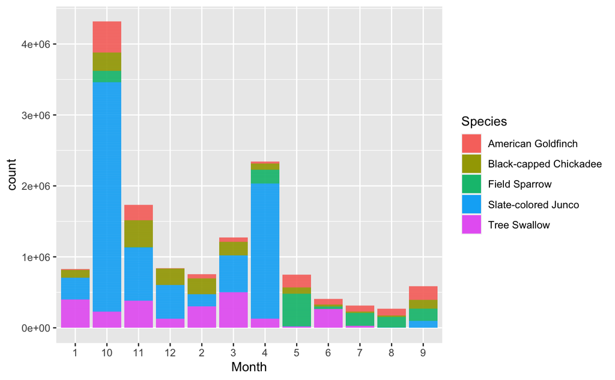

According to the graph, we can answer the questions posed:

##### 2. Which species are migratory, that is, primarily present in one or two seasons?

The Field Sparrow.

##### 3. What is the peak month for each major species? (bullet list)

-American Goldfinch: month 10 -Black-capped Chickadee: month 11 -Field Sparrow: month 5 -Slated-colored Junco: month 10 -Tree Swallow: month 3

##### 4. Which major species are seen in good numbers for at least 6 months of the year?

The Slated-colored Junco and the Tree Swallow.